# Analysis Protocol

Christian Diener, Osbaldo Resendis

# Installation

This repository is structured to enable easy installation of the required dependencies. This is enabled by the `prtools` R package that serves two major purposes:

1. It includes auxiliary functions and tests that are used during the analysis
2. It depends on all other R packages that are used throughout the analysis. Thus, installing the `prtools` package will also ensure that all other required packages are installed.

We also provide a Docker container which has everything pre-installed and can be used to run the analysis on a server in the cloud.

This repository also includes `<step>.R` files for all steps of the analysis which you can use to run parts of the analysis in an automated manner. Additional data file are also contained in this repository. In order to obtain a local copy you can clone the repository with [git](https://git-scm.org).

```bash
git clone cdiener/proliferation
```

## Local installation

For a local installation you will require `R` installed (see http://r-project.org for installation instructions). You will also require `Python` and `cobrapy` if you want to run the metabolic modeling part of the analysis.

To install the R dependencies, first install bioconductor and devtools if you do not have them installed already. Start up R and use the following:

```r
install.packages("devtools")
source("https://bioconductor.org/biocLite.R")
biocLite()
```

After that you can install `prtools` simply via

```r
devtools::install_github("cdiener/proliferation/prtools")
```

Loading the prtools package will then also load all additional packages we will use:

```r
library(prtools)
```

If you want to download the raw analysis data you will also need the GDC data transfer tool. Installation instructions can be [found here](https://gdc.cancer.gov/access-data/gdc-data-transfer-tool). Please make sure that the `gdc-client` executable is in your path. The docker image already includes the tool.

```bash
pip install cobra
```

## Using the docker image

In order to run this image in the cloud you will need a server with docker installed. The easiest way to do so is to start a virtual machine that already has it installed such as the [CoreOS](https://coreos.com/) machines on Amazon AWS, Google Cloud or Digital Ocean.

Having logged in to your cloud or local server get the docker image with

```bash
docker pull cdiener/proliferation
```

Then run the following on your local machine or cloud server:

```bash
docker run -d -p 8000:8787 cdiener/proliferation
```

Now navigate to http://your-ip:8000 (on your local machine the IP will be “localhost”) or your server in the cloud in order to see an Rstudio client. You will be prompted for a user and password which are both set to “rstudio” by default.

# Getting the data

We will start by getting all the required data. You will need about 40 GB of disk space for all the downloads. This step is the longest during this analysis.

First, we will download the HuEx 1.0 ST exon expression data for the NCI-60 cell lines using the `GEOquery` package (about 9 GB).

```r
GEOquery::getGEOSuppFiles("GSE29682")
untar("GSE29682/GSE29682_RAW.tar", exdir="GSE29682")
```

We follow this by downloading all relevany TCGA data from the Genomic Data Commons (GDC) as well (19 GB). For that you will need a file manifest generated from the [GDC data portal](https://gdc-portal.nci.nih.gov/search/s). Here, we use the tcgar package which we wrote specifically for this analysis. We will save the data into the `GDC` subfolder with another subfolder for each data type. File manifests for the data used in this analysis are already provided in the `GDC` folder.

```r
get_data("GDC/manigest_tcga_rnaseq", "GDC/rnaseq")
get_data("GDC/manigest_tcga_huex", "GDC/huex")
get_data("GDC/manigest_tcga_clinical", "GDC/clinical")
```

Note that this will take a long time.

Finally, we will also get annotations that relate all the genes from the NCI-60 and TCGA data sets. Here, we will employ biomart to obtain mappings between the probes on the HuEx microarrays and several Gene ID systems. This step is optional since the generated `probemap.rds` file is contained in the repository as well.

```r
ensembl = useMart("ensembl",dataset="hsapiens_gene_ensembl")
attrs <- c("ensembl_gene_id", "description", "external_gene_name", "ucsc",
    "entrezgene", "affy_huex_1_0_st_v2")
probemap <- getBM(mart=ensembl, attributes=attrs)
probemap <- data.table(probemap)
names(probemap) <- c("ensgene", "description", "symbol", "ucsc", "entrez", "huex")
saveRDS(probemap, "probemap.rds")
```

# Preprocessing exon expression data

## Normalization and summary

We will start by preparing the HuEx exon expression data for the NCI-60 data set. Here, we will read all of the raw files, calculate the log expression values and normalize the arrays with RMA. This will take about 16 GB of RAM and take a while. If you have several cores available on your machine we recommend to use them here. To use 6 cores during computations you may use the following:

```r
registerDoMC(6)
```

Finally, we will save this raw expression set to a serialized format, so we do not have to repeat this step every time. This will take about half an hour.

```r
if (file.exists("eset_raw.rds")) eset <- readRDS("eset_raw.rds") else {
    celfiles <- list.celfiles(recursive=T, listGzipped=T)
    raw_data <- read.celfiles(celfiles)
    eset <- rma(raw_data, target="probeset")
    rm(raw_data)
    saveRDS(eset, file="eset_raw.rds")
}
```

The expression values we obtain this way are on the level of “probe sets”, sets of spots on the microarray. However, in order to obtain expression values per gene we have to summarize those probe set expression values. For this we can use `probemap.rds` mapping that we obtained earlier. First, we will prepare the probe map to give us unique mappings between genes and probe sets. We will only consider genes that map to a probe set that is present on our arrays and we will also only use probe sets that map to a gene with a known ENSEMBL ID.

```r
probemap <- readRDS("probemap.rds")
probemap <- unique(probemap, by=c("ensgene", "huex"))
probemap[, huex := as.character(huex)]
setkey(probemap, huex)
eset <- eset[rownames(eset) %in% probemap$huex, ]
probemap <- probemap[huex %in% rownames(eset) & !is.na(ensgene)]
```

We now have a mapping of probe sets to genes and vice versa. We will use that to summarize the log gene expression values into the geometric mean for each gene. For that we can use the `eset_reduce` function from the `prtools` package which does that rapidly (because it is implemented in C++).

```r
eset <- eset_reduce(eset, probemap$huex, probemap$ensgene)
```

## Joining with proliferation data

We now have the per-gene log expression values for each of the 178 microarrays in our data set. In order to map those arrays to their respective cell line we can use the annotations contained in `samples.csv`:

```r
samples <- fread("samples.csv")
head(samples)
```

```
##       geo_id  tumor  cell_line
## 1: GSM736050 Breast     BT-549
## 2: GSM736051 Breast     HS578T
## 3: GSM736052 Breast       MCF7
## 4: GSM736053 Breast MDA-MB-231
## 5: GSM736054 Breast       T47D
## 6: GSM736055    CNS     SF-268
```

So we see that there are 2-3 reptitions for each cell line. The actual growth rates are contained in `growth_rates.csv`:

```r
gcs <- fread("growth_rates.csv")
head(gcs)
```

```
##    cell_line panel_name doubling_time inoculation_density
## 1:  CCRF-CEM   Leukemia          26.7               40000
## 2:     HL-60   Leukemia          28.6               40000
## 3:     K-562   Leukemia          19.6                5000
## 4:    MOLT-4   Leukemia          27.9               30000
## 5: RPMI-8226   Leukemia          33.5               20000
## 6:        SR   Leukemia          28.7               20000
```

Now, we will reduce the individual repetitions for each cell line to its mean log expression values and relate the cell lines in the microarray samples to the ones in the growth rate data set.

```r
setkey(gcs, cell_line)
cell_lines <- intersect(gcs$cell_line, samples$cell_line)
eset_summ <- sapply(cell_lines, function(cl) rowMeans(exprs(eset)[,samples$cell_line==cl]))
colnames(eset_summ) <- cell_lines
```

Right, now proliferation is given in doubling time (in hours), so we will convert those to proliferation rates and also run a quick check whether the proliferation rates are ordered the same way as the microarray samples.

```r
rates <- gcs[cell_lines, log(2)/doubling_time]
names(rates) <- cell_lines
if (all(colnames(eset_summ) == names(rates))) cat("Ordering is the same :)")
```

```
## Ordering is the same :)
```

## Exporting the regression problem

Finally, we will attach the proliferation rates as an aditional columns to the expression values, thus, each row now denotes a cell line, and each column a gene, where only the last column denotes the proliferation rates. This is a common format for regression and classification problems and we will save it in csv format, so that it can be used easily in other software.

```r
export <- data.table(t(eset_summ))
export[, "rates" := rates]
readr::write_csv(export, "regprob.csv")
```

# Preparing TCGA data

## Reading the data

First we will start by reading the TCGA data into RAM. The `tcgar` package does this efficiently. We will store the results in a list with one sublist for each technology (this will take around 20 minutes depending on your server).

```r
library(tcgar)
tcga <- list(
    rnaseq = read_rnaseq("GDC/manifest_tcga_rnaseq.tsv", "GDC/rnaseq", progress=F),
    huex = read_huex("GDC/manifest_tcga_huex.tsv", "GDC/huex", progress=F),
    clinical = read_clinical("GDC/manifest_tcga_clinical.tsv", "GDC/clinical", progress=F)
)
```

Again, we will save the output in a serialized file.

```r
saveRDS(tcga, "tcga.rds")
```

If you downloaded the preprocessed data you can skip the previous steps and read it directly using:

```r
tcga <- readRDS("tcga.rds")
```

## Comparison to NCI-60 cell line data

In order to compare gene expression between the TCGA RNA-Seq data and NCI-60 microarrays we will need to create a data set that contains the mean expression values for all genes that are contained in the TCGA *and* NCI-60 data. For that, we begin by calculating the mean log expression values across all samples within the TCGA and NCI-60 data (RNA-Seq abundances are measured in counts, so we have to add a pseudo count in order to obtain the log). We begin by calculating the means for the RNA-Seq and HuEx data contained in the TCGA data set.

```r
all_rnaseq <- log(rowMeans(tcga$rnaseq$counts)+1, 2)
all_rnaseq <- data.table(ensgene=tcga$rnaseq$features$ensgene,
    tcga_rnaseq=all_rnaseq)
all_huex <- data.table(symbol=tcga$huex$features$symbol,
    tcga_huex=rowMeans(tcga$huex$assay))
```

We also do the same for the NCI-60 HuEx data.

```r
nci60 <- fread("regprob.csv", header=T)
rates <- nci60$rates
nci60[, rates := NULL]
all_nci60 <- data.table(ensgene=colnames(nci60), nci60_huex=colMeans(nci60))
```

We will now join those data sets by mapping their respective IDs. `tcgar` already comes with a table mapping the genes in TCGA between different IDs, `genemap`.

```r
join <- merge(as.data.table(tcgar::genemap), all_nci60, by="ensgene")
join <- merge(join, all_huex, by="symbol")
join <- merge(join, all_rnaseq, by="ensgene")
head(join)
```

```
##            ensgene   symbol
## 1: ENSG00000000003   TSPAN6
## 2: ENSG00000000005     TNMD
## 3: ENSG00000000419     DPM1
## 4: ENSG00000000457    SCYL3
## 5: ENSG00000000460 C1orf112
## 6: ENSG00000000938      FGR
##                                                                                                   description
## 1:                                                          tetraspanin 6 [Source:HGNC Symbol;Acc:HGNC:11858]
## 2:                                                            tenomodulin [Source:HGNC Symbol;Acc:HGNC:17757]
## 3: dolichyl-phosphate mannosyltransferase polypeptide 1, catalytic subunit [Source:HGNC Symbol;Acc:HGNC:3005]
## 4:                                               SCY1-like, kinase-like 3 [Source:HGNC Symbol;Acc:HGNC:19285]
## 5:                                    chromosome 1 open reading frame 112 [Source:HGNC Symbol;Acc:HGNC:25565]
## 6:                          FGR proto-oncogene, Src family tyrosine kinase [Source:HGNC Symbol;Acc:HGNC:3697]
##    entrez nci60_huex tcga_huex tcga_rnaseq
## 1:   7105   6.102991  9.232960   11.795649
## 2:  64102   4.281391  4.533475    6.336445
## 3:   8813   7.650315  8.091734   10.909042
## 4:  57147   5.985178  6.499165    9.908830
## 5:  55732   6.206742  5.850941    9.004820
## 6:   2268   6.113765  6.895676    9.491145
```

Sometimes, those mapping between IDs are not unique, which makes it impossible to identify unique gene expression values. We will remove those cases.

```r
dupes <- join$ensgene[duplicated(join$ensgene)]
print(sum(join$ensgene %in% dupes))
```

```
## [1] 0
```

```r
join <- join[!(join$ensgene %in% dupes), ]
saveRDS(join, "join.rds")
```

That gives us our joined gene expression data set.

## Identifying genes with conserved expression

In order to use gene expression data from the NCI-60 data set for predictions on the TCGA data set, we first have to find a set of genes with very similar expression values between cell lines and human samples. As described in the manuscript, we consider gene expression to be conserved if the expression values are correlated, meaning that the gene expression values between the two data sets follow a linear relationship. We could estimate the slope and intercept directly from TCGA RNA-Seq and NCI-60 HuEx data, however, a more stable approach is to estimate both parameters independently from additional data we have.

### Estimating the intercept

The intercept describes a constant difference in log expression values between the two data set. We can estimate is simply by using data obtained with the same technology between the two data sets. Since we have HuEx expression data from NCI-60 as well as the TCGA data set, the intercept can be calculated as the difference in mean between the HuEx data sets.

```r
norm_int <- mean(join$nci60_huex) - mean(join$tcga_huex)
```

As we can see, using this correction both HuEx data sets relate well with each other.

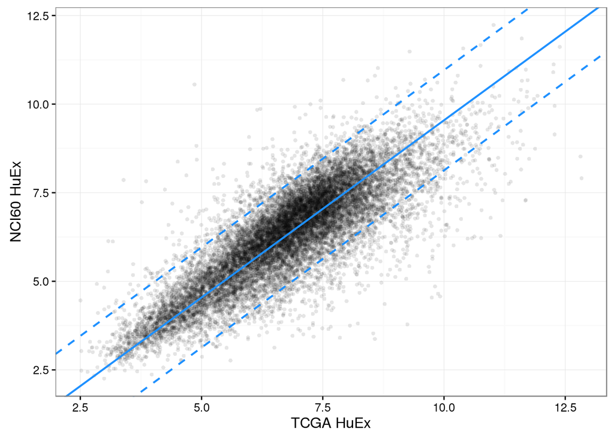

```r
ggplot(join, aes(x=tcga_huex, y=nci60_huex)) + geom_point(alpha=0.1, stroke=0) +
    geom_abline(intercept=norm_int, size=3/4, col="dodgerblue") +
    geom_abline(intercept=sqrt(2)+norm_int, size=3/4, col="dodgerblue", linetype="dashed") +
    geom_abline(intercept=-sqrt(2)+norm_int, size=3/4, col="dodgerblue", linetype="dashed") +
    xlab("TCGA HuEx") + ylab("NCI60 HuEx") + theme_bw()
```

Here, the dashed blue lines denote the area in which genes have a maximum distance of 1 from the 1:1 relation denotes by the solid blue line.

### Estimating the slope

The slope of the linear relationship denotes a difference between technologies. It can be obtained by comparing the two technologies, HuEx and RNA-Seq, within the same data set.

```r
norm <- coef(glm(tcga_huex ~ tcga_rnaseq + 0, data=join))
```

Again, we see that the majority of genes follows this relationship. However, there also some genes whose expression values are not comparable, even within the TCGA data set.

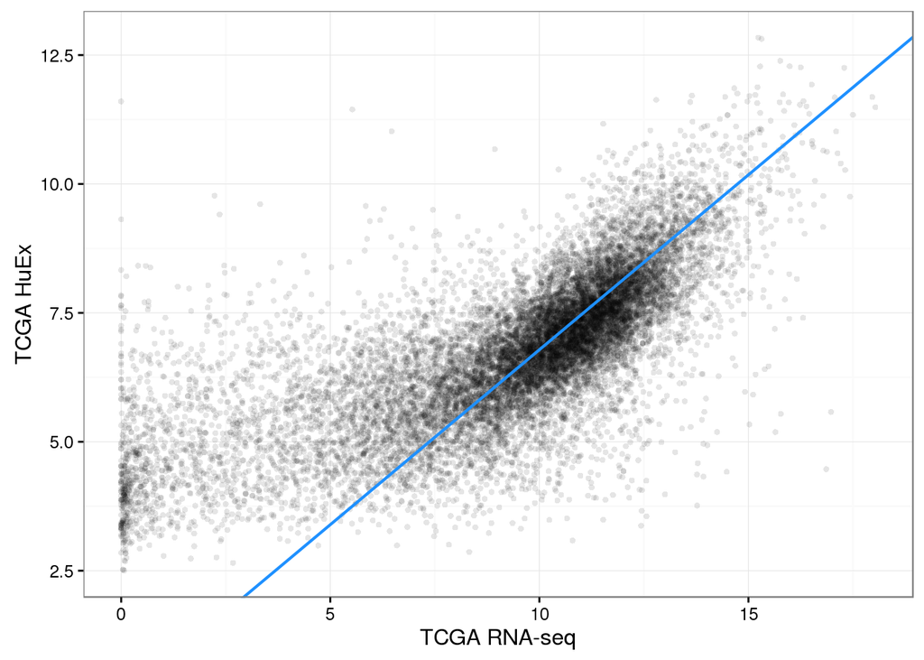

```r
ggplot(join, aes(x=tcga_rnaseq, y=tcga_huex)) + geom_point(alpha=0.1, stroke=0) +
    geom_abline(slope=norm, size=3/4, col="dodgerblue") +
    xlab("TCGA RNA-seq") + ylab("TCGA HuEx") + theme_bw()
```

### Validation

Finally, we can validate the two parameters by using the TCGA RNA-Seq data and the NCI-60 HuEx data.

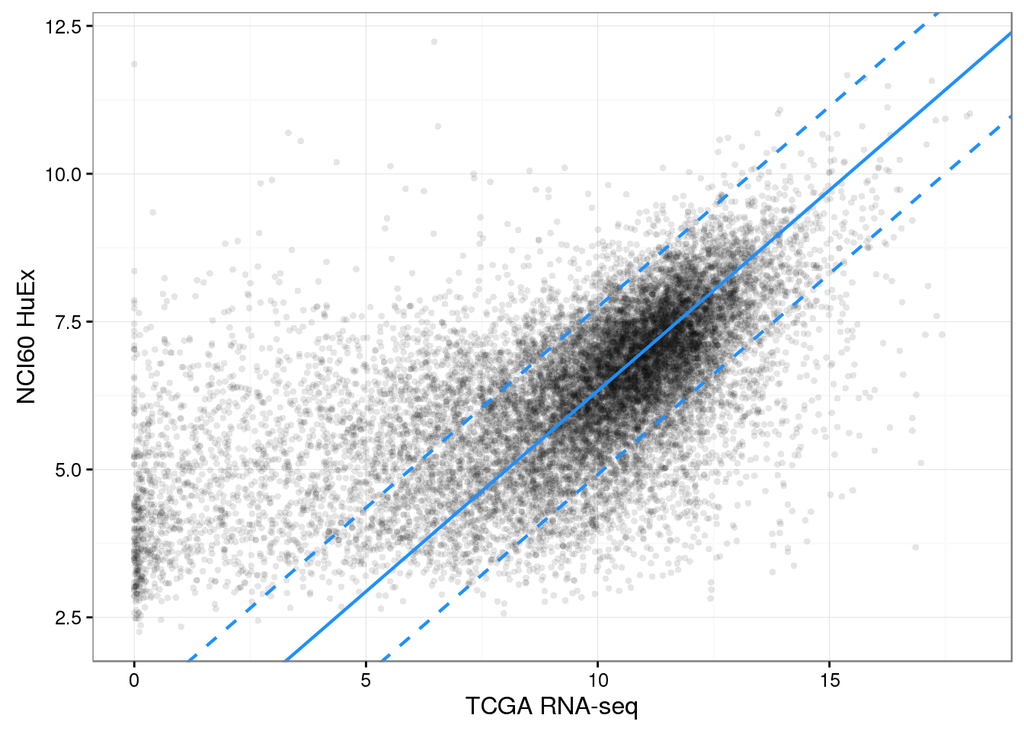

```r
norm <- c(norm, norm_int)
saveRDS(norm, "norm_factor.rds")
ggplot(join, aes(x=tcga_rnaseq, y=nci60_huex)) + geom_point(alpha=0.1, stroke=0) +
    geom_abline(slope=norm, intercept=norm_int, size=3/4, col="dodgerblue") +
    geom_abline(slope=norm, intercept=sqrt(2)+norm_int, size=3/4,
    col="dodgerblue", linetype="dashed") +
    geom_abline(slope=norm, intercept=-sqrt(2)+norm_int, size=3/4,
    col="dodgerblue", linetype="dashed") +
    xlab("TCGA RNA-seq") + ylab("NCI60 HuEx") + theme_bw()
```

```r
measures(join$nci60_huex, norm[1] * join$tcga_rnaseq + norm[2])
```

```
##        mse       rmse        mae        mre        rsq
##  3.2855448  1.8126072  1.2590307  0.2276717 -0.6511785
```

Using both parameters we see a good agreement between the data, however, there are also genes that do not follow the linear relationship. Since, we are only interested in genes with a conserved expression across the two data sets, we will only consider genes in the further analysis that do not differ by a log fold change more than 1 between the two normalized data sets (area enclosed by dashed blue lines).

# Regression and prediction

We now have a way of normalizing the gene expression data between TCGA and NCI-60 and a criterion to select conserved genes only. Thus, we can now start with the regression problem. We start by reading the regression problem again.

```r
rdata <- fread("regprob.csv", header=T)
```

But this time we will only select the genes that conserved (difference in normalized log expression smaller than one).

```r
cutoff <- 1
good <- join[(tcga_rnaseq*norm[1] + norm[2] - nci60_huex)^2 < cutoff &
    (tcga_huex + norm[2] - join$nci60_huex)^2 < cutoff, ensgene]
rates <- rdata$rates
rdata[, "rates" := NULL]
rdata <- as.matrix(rdata)[, good]
dim(rdata)
```

```
## [1]   57 7799
```

We will now test a total of 4 different generalized linear models.

## Tested models

We will use the LASSO generalized linear models from the `glmnet` package. We will also initialize two data frames that will contain all the predictions and goodnes-of-fit metrics. Those will be calculated for each of the models on the training set and leave-one-out cross validation.

```r
library(glmnet)

pred <- data.frame()
m <- data.frame()

# For leave-one-out cross validation
folds <- length(rates)
```

### First order model

In the first model gene expression values enter as linear variables into the model. We will extract the predictions on the training set as well as predictions from leave-one-out cross validation.

```r
mod1 <- cv.glmnet(rdata, rates, nfolds=folds, keep=T, parallel=T,
    grouped=FALSE, standardize=FALSE)
pred_train <- predict(mod1, rdata, s="lambda.min")[,1]
pred_test <- mod1$fit.preval[, which.min(mod1$cvm)]
```

We now append the predicted rates and performance measures to our data frames.

```r
pred <- rbind(pred, data.frame(truth=rates, pred=pred_train, set="train", order="1st"))
pred <- rbind(pred, data.frame(truth=rates, pred=pred_test, set="validation", order="1st"))
m <- rbind(m, data.frame(t(measures(rates, pred_train)), set="train", order="1st"))
m <- rbind(m, data.frame(t(measures(rates, pred_test)), set="validation", order="1st"))
```

### Second order model

In the second order model we will only consider interactions between gene expression values, meaning products between two gene expression values. Because of the large number of candidate genes it would be feasible to test all combinations. Instead we will only consider interactions between those genes that non-zero coefficients in the first order model.

```r
nonzero <- abs(coef(mod1, s="lambda.min")[-1]) > 0
data2 <- inter(rdata[,nonzero])
mod2 <- cv.glmnet(data2, rates, nfolds=folds, keep=T, parallel=T,
    grouped=FALSE, standardize=FALSE)
pred_train <- predict(mod2, data2, s="lambda.min")[,1]
pred_test <- mod2$fit.preval[, which.min(mod2$cvm)]
pred <- rbind(pred, data.frame(truth=rates, pred=pred_train, set="train", order="2nd"))
pred <- rbind(pred, data.frame(truth=rates, pred=pred_test, set="validation", order="2nd"))
m <- rbind(m, data.frame(t(measures(rates, pred_train)), set="train", order="2nd"))
m <- rbind(m, data.frame(t(measures(rates, pred_test)), set="validation", order="2nd"))
```

### First and second order model

In this model we will use the same interaction terms as before but also add all the original gene expression values in order to see whether the model can be improved.

```r
data12 <- cbind(rdata[, nonzero], data2)
mod3 <- cv.glmnet(data12, rates, nfolds=folds, keep=T, parallel=T,
    grouped=FALSE, standardize=FALSE)
pred_train <- predict(mod3, data12, s="lambda.min")[,1]
pred_test <- mod3$fit.preval[, which.min(mod3$cvm)]
pred <- rbind(pred, data.frame(truth=rates, pred=pred_train, set="train", order="1st and 2nd"))
pred <- rbind(pred, data.frame(truth=rates, pred=pred_test, set="validation", order="1st and 2nd"))
m <- rbind(m, data.frame(t(measures(rates, pred_train)), set="train", order="1st and 2nd"))
m <- rbind(m, data.frame(t(measures(rates, pred_test)), set="validation", order="1st and 2nd"))
```

As we can see, adding the first order terms does not improve the second order model.

### Regularized model by cutoff

Finally, we will try to improve the generalization of the model, by removing those interactions that have only very influences on the model and may thus be related to overfitting.

```r
cf <- as.numeric(coef(mod2, s="lambda.min"))[-1]
names(cf) <- rownames(coef(mod2))[-1]
nonzero <- abs(cf) > quantile(abs(cf[abs(cf) > 0]), 0.25)
data_red <- data2[, nonzero]
mod <- cv.glmnet(data_red, rates, nfolds=folds, keep=T,
    grouped=FALSE, standardize=FALSE)
pred_train <- predict(mod, data_red, s="lambda.min")[,1]
pred_test <- mod$fit.preval[, which.min(mod$cvm)]
pred <- rbind(pred, data.frame(truth=rates, pred=pred_train, set="train", order="2nd + cutoff"))
pred <- rbind(pred, data.frame(truth=rates, pred=pred_test, set="validation", order="2nd + cutoff"))
m <- rbind(m, data.frame(t(measures(rates, pred_train)), set="train", order="2nd + cutoff"))
m <- rbind(m, data.frame(t(measures(rates, pred_test)), set="validation", order="2nd + cutoff"))
print(sum(nonzero))
```

```
## [1] 38
```

## Model selection

If we compare the goodness-of-fit measures we can see that the cutoff model shows good good performance with an error of about 4% in predicting proliferation rates.

goodnes-of-fit measures

| mse | rmse | mae | mre | rsq | set | order |
| --- | --- | --- | --- | --- | --- | --- |
| 2.00e-07 | 0.0004688 | 0.0003391 | 0.0163479 | 0.9960625 | train | 1st |
| 4.49e-05 | 0.0067003 | 0.0052876 | 0.2611128 | 0.1958045 | validation | 1st |
| 2.00e-07 | 0.0004420 | 0.0003570 | 0.0169304 | 0.9965005 | train | 2nd |
| 8.10e-06 | 0.0028480 | 0.0022301 | 0.1047906 | 0.8547042 | validation | 2nd |
| 2.00e-07 | 0.0004420 | 0.0003570 | 0.0169304 | 0.9965005 | train | 1st and 2nd |
| 8.10e-06 | 0.0028480 | 0.0022301 | 0.1047906 | 0.8547042 | validation | 1st and 2nd |
| 1.00e-07 | 0.0003543 | 0.0002643 | 0.0132028 | 0.9977519 | train | 2nd + cutoff |
| 1.00e-06 | 0.0010053 | 0.0008111 | 0.0398894 | 0.9818972 | validation | 2nd + cutoff |

This can also be observed visually by plotting the real proliferation rates against the predicted ones (a perfect match would create a 1:1 line).

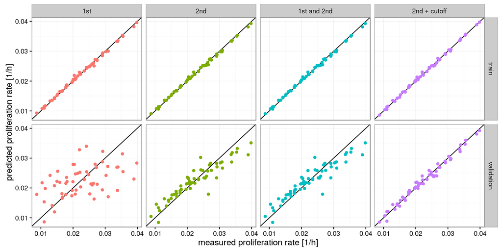

```r
ggplot(pred, aes(x=truth, y=pred, col=order)) + geom_abline() +
    geom_point() + facet_grid(set ~ order) + theme_bw() +
    xlab("measured proliferation rate [1/h]") +
    ylab("predicted proliferation rate [1/h]") +
    theme(legend.position="none")
```

We will also save a list of the gene interactions and coefficient values for the final model.

```r
genes <- do.call(rbind, strsplit(colnames(data_red), "x"))
colnames(genes) <- c("gene1", "gene2")
write.csv(data.frame(genes, coef=cf[nonzero]), "best_interactions.csv")
```

## Prediction of proliferation rates

We now have our trained model and will continue predicting proliferation rates for the samples from TCGA.

### Prediction for HuEx samples

The major problem we have is that in the HuEx data genes are identified by symbols whereas our interaction terms are identied by ENSEMBL gene ids. So we will begin by creating a mapping between the two using the gene map from before and getting the symbols for our genes in the interaction terms.

```r
map <- genemap
setkey(map, ensgene)
symbs <- cbind(map[genes[,1], symbol], map[genes[,2], symbol])
```

With that we can get the expression values for those genes and normalize them with the normalization factor we obtained earlier.

```r
huex_ex <- tcga$huex$assay[unique(as.vector(symbs)), ]
huex_ex <- huex_ex + norm[2]
```

We can now calculate the corresponding interaction terms and predict the proliferation rates for all samples. Here, we will also remove internal controls that do not map to any TCGA samples.

```r
huex_red <- t(huex_ex[symbs[,1], ] * huex_ex[symbs[,2], ])
colnames(huex_red) <- paste0(symbs[,1], "x", symbs[,2])
rates_huex <- predict(mod, huex_red, s="lambda.min")[,1]
controls <- is.na(names(rates_huex))
rates_huex <- rates_huex[!controls]
```

### Prediction for RNA-Seq samples

RNA-Seq samples are identified by ENSEMBL ids as well so we can advance straight away to calculating the log expression values and applying the normalization.

```r
rna_ex <- tcga$rnaseq$counts[unique(as.vector(genes)), ]
rna_ex <- log(rna_ex+1, 2)
rna_ex <- rna_ex * norm[1] + norm[2]
```

With that we can calculate the interaction terms and predict the proliferation rates.

```r
rna_red <- t(rna_ex[genes[,1], ] * rna_ex[genes[,2], ])
colnames(rna_red) <- paste0(genes[,1], "x", genes[,2])
rates_rna <- predict(mod, rna_red, s="lambda.min")[,1]
```

### Combining the data sets

Finally we will first create a prediction data set that combines all proliferation rate predictions together with the sample annotations.

```r
pred <- data.table(
    patient_barcode=c(tcga$rnaseq$samples$patient_barcode,
        tcga$huex$samples$patient_barcode[!controls]),
    panel=c(tcga$rnaseq$samples$panel, tcga$huex$samples$panel[!controls]),
    rates=c(rates_rna, rates_huex),
    tumor=c(tcga$rnaseq$samples$tumor, tcga$huex$samples$tumor[!controls])
    )
```

```r
sum(pred$rates)/nrow(pred)
```

```
## [1] 0.01766423
```

We can merge this data set with the clinical information for each patient now.

```r
comb <- merge(pred, tcga$clinical, by=c("patient_barcode", "panel"))
print(comb)
```

```
##        patient_barcode panel      rates tumor
##     1:    TCGA-02-0001   GBM 0.02420641  TRUE
##     2:    TCGA-02-0003   GBM 0.03418276  TRUE
##     3:    TCGA-02-0004   GBM 0.01989495  TRUE
##     4:    TCGA-02-0006   GBM 0.02384004  TRUE
##     5:    TCGA-02-0007   GBM 0.03056712  TRUE
##    ---
## 12107:    TCGA-ZS-A9CG  LIHC 0.01406726  TRUE
## 12108:    TCGA-ZT-A8OM  THYM 0.03907078  TRUE
## 12109:    TCGA-ZU-A8S4  CHOL 0.02606463  TRUE
## 12110:    TCGA-ZU-A8S4  CHOL 0.02548018 FALSE
## 12111:    TCGA-ZX-AA5X  CESC 0.02485634  TRUE
##                                patient_uuid gender vital days_to_contact
##     1: 30a1fe5e-5b12-472c-aa86-c2db8167ab23 female  Dead             279
##     2: df3c1d61-79c1-43e9-971a-8029497ffeab   male  Dead             144
```

[output cut: 45 more lines]

Finally we will save those data sets for later usage.

```r
saveRDS(comb, "combined.rds")
write.csv(pred, "pred_rates.csv")
```

# Proliferation rates and their association with clinical data

## General properties

Having the combined data set `comb` most of the following analyses are straight forward. First we can visualize the overall distribution of proliferation rates across the TCGA cancer panels.

```r
means <- pred[, list(val=median(rates)), by=panel]
setkey(pred, panel)
pred <- pred[means[order(val), panel]]
pred[, panel := factor(panel, levels=unique(panel))]
```

followed by plotting them with `ggplot2`.

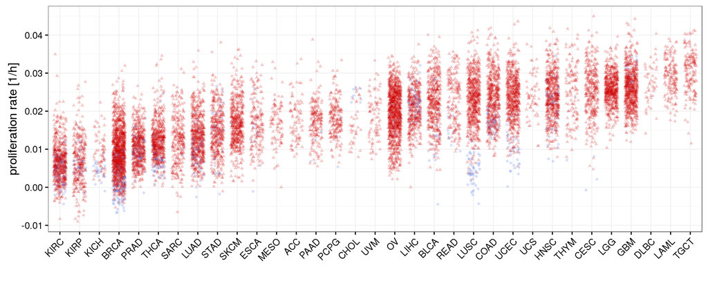

```r
ggplot(pred, aes(x=panel, y=rates, color=tumor, shape=tumor)) +
    geom_jitter(alpha=0.2, width=0.8, height=0, size=1) + theme_bw() + theme(axis.text.x =
    element_text(angle = 45, vjust = 1, hjust=1), legend.position="none") +
    xlab("") + ylab("proliferation rate [1/h]") +
    scale_colour_manual(values=c("royalblue", "red3"))
```

```r
# Return panels to its original state
pred[, panel := as.character(panel)]
```

Here red triangles denote cancer samples and blue circles samples from healthy tissues.

We can also check how the proliferation rates from tumor and normal tissue samples behave.

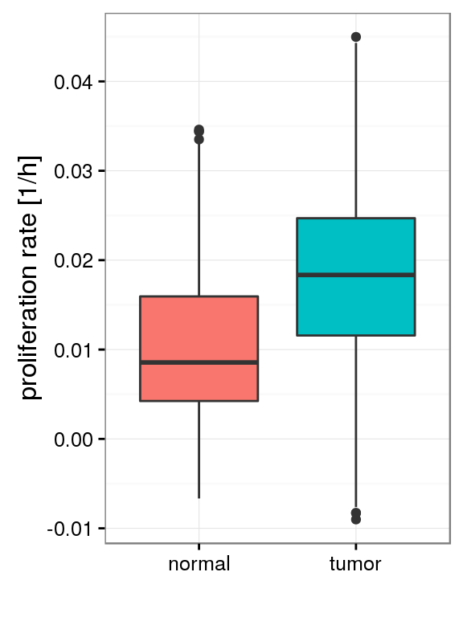

```r
ggplot(pred, aes(x=c("normal", "tumor")[tumor+1], y=rates, fill=tumor)) +
    geom_boxplot() + xlab("") + ylab("proliferation rate [1/h]") + theme_bw() +
    theme(legend.position="none")
```

Here, the fold-change between tumor and normal tissue is given by

```r
pred[(tumor), mean(rates)] / pred[!(tumor), mean(rates)]
```

```
## [1] 1.748735
```

And this difference can be tested with a wilcoxon ranked-sum test.

```r
wilcox.test(pred[!(tumor), rates], pred[(tumor), rates], conf.int=TRUE)
```

```
##
##  Wilcoxon rank sum test with continuity correction
##
## data:  pred[!(tumor), rates] and pred[(tumor), rates]
## W = 2259800, p-value < 2.2e-16
## alternative hypothesis: true location shift is not equal to 0
## 95 percent confidence interval:
##  -0.008912064 -0.007526168
## sample estimates:
## difference in location
##           -0.008210716
```

## Survival Analysis

First we will set up the times and censoring. The `comb` data set includes the required information in the `days_to_death`, `days_to_contact` and `vital` columns.

```r
days_per_year <- 365.25

comb <- comb[!is.na(vital) & tumor]
delta <- c(comb[vital=="Alive", days_to_contact/days_per_year],
    comb[vital=="Dead", days_to_death/days_per_year])
status <- comb$vital == "Dead"
```

For visualization we will stratify the survival data into two groups. One including the top 25% of proliferation rates and the other containing the bottom 25%.

```r
prolif <- vector(length=nrow(comb))
prolif[comb$rates > quantile(comb$rates, .75)] <- "high"
prolif[comb$rates < quantile(comb$rates, .25)] <- "low"
prolif <- factor(prolif, levels=c("low", "high"))
```

We can now generate the survival fit and create the corresponding Kaplan-Meier plot.

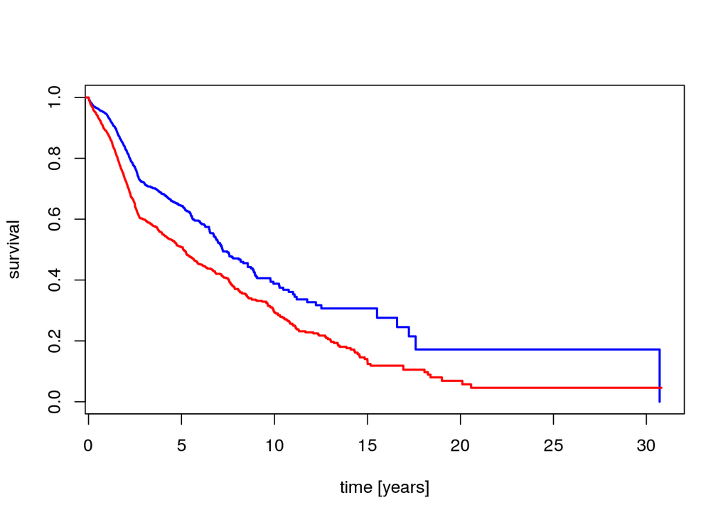

```r
surv <- Surv(delta, status)
fit <- survfit(surv ~ prolif)
plot(fit, col=c("blue", "red"), xlab="time [years]", ylab="survival", lwd=2)
```

However, the proliferation rate is a continuous variable and we would like to evaluate its association to survival without creating artificial strata. For this we can use a Cox proportional hazards model.

```r
coxm <- coxph(surv ~ comb$rates)
print(coxm)
```

```
## Call:
## coxph(formula = surv ~ comb$rates)
##
##                coef exp(coef) se(coef)    z      p
## comb$rates 1.67e+01  1.75e+07 1.87e+00 8.93 <2e-16
##
## Likelihood ratio test=80.3  on 1 df, p=0
## n= 11337, number of events= 3836
##    (63 observations deleted due to missingness)
```

We can use the parameter β to calculate the increase in risk when increasing the proliferation rate by a fixed value, for instance 0.01:

```r
exp(coef(coxm) * 0.01)
```

```
## comb$rates
##   1.181475
```

So this would mean an increased risk of about 18%.

## Association with tumor stage

We can also study how the tumor stage relates to the predicted proliferation rates. We will use the [TNM staging system here](http://www.cancer.gov/about-cancer/diagnosis-staging/staging). The pathological tumor stages are already contained in `comb`, however they may have several subtypes. So we will clean them up a bit to only leave the major tumor stages such as “T1”, “N2”, “Stage III”, etc.

```r
comb[, T := gsub("[a-e][0-9]*$", "", T)]
comb[, N := gsub("[^0-4NX]", "", N)]
comb[, M := gsub("[^0-4MX]", "", M)]
comb[stage %in% c("I/II NOS", "IS"), stage := NA]
comb[, stage := gsub("[A-C]*$", "", stage)]
```

This enables us to visualize the proliferation rates across the TNM staging system.

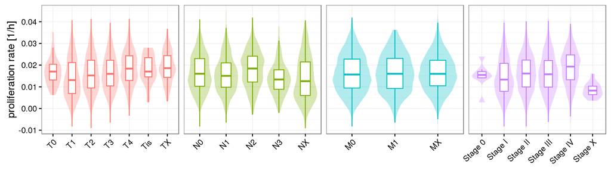

```r
x <- melt(comb[, .(rates, panel, T, N, M, stage)], id.vars=c("rates", "panel"))
ggplot(x, aes(x=value, y=rates, col=variable)) +
    geom_violin(aes(fill=variable), scale="width", alpha=0.3, linetype=0) +
    geom_boxplot(outlier.colour=NA, width=0.5) +
    facet_wrap(~ variable, scales="free_x", nrow=1) + theme_bw() +
    theme_bw() + theme(axis.text.x = element_text(angle = 45, vjust = 1,
    hjust=1), legend.position="none", strip.text = element_blank()) +
    ylab("proliferation rate [1/h]") + xlab("")
```

As we can see there is again a lot of heterogeneity going on. We can test for associations by the non-parametric Kruskal-Wallis test.

```r
kw_tests <- x[, kruskal.test(rates, factor(value)), by=variable]
print(kw_tests)
```

```
##    variable  statistic parameter      p.value                       method
## 1:        T 194.685979         6 2.564358e-39 Kruskal-Wallis rank sum test
## 2:        N 147.075919         4 8.614847e-31 Kruskal-Wallis rank sum test
## 3:        M   1.720631         2 4.230285e-01 Kruskal-Wallis rank sum test
## 4:    stage 184.017226         5 7.418813e-38 Kruskal-Wallis rank sum test
##                  data.name
## 1: rates and factor(value)
## 2: rates and factor(value)
## 3: rates and factor(value)
## 4: rates and factor(value)
```

# Flux predictions and metabolic liabilities

$\begin{align} &\min_i \sum_i v_i\\ s.t.\quad& \mathbf{Sv} = 0\\ & v_p = r_p\\ & v_i \geq 0 \end{align}$